# limiares

#### Allegro

0.1 [1] “

"

#### Evolução dos desenvolvedores ao longo do tempo

( janela 24 semanas, iteracao de 4 semanas) [1] “

"

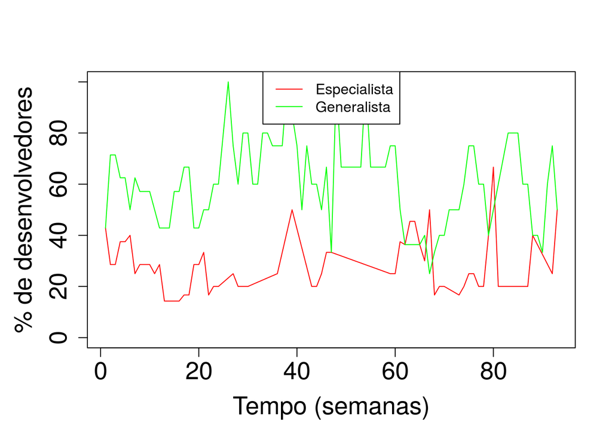

|  | esp | gen |
| --- | --- | --- |
| twosided | 0.8007013 | 0.4935806 |
| greater | 0.4003507 | 0.7532097 |
| less | 0.5996493 | 0.2467903 |

#### Allegro

0.2 [1] “

"

#### Evolução dos desenvolvedores ao longo do tempo

( janela 24 semanas, iteracao de 4 semanas) [1] “

"

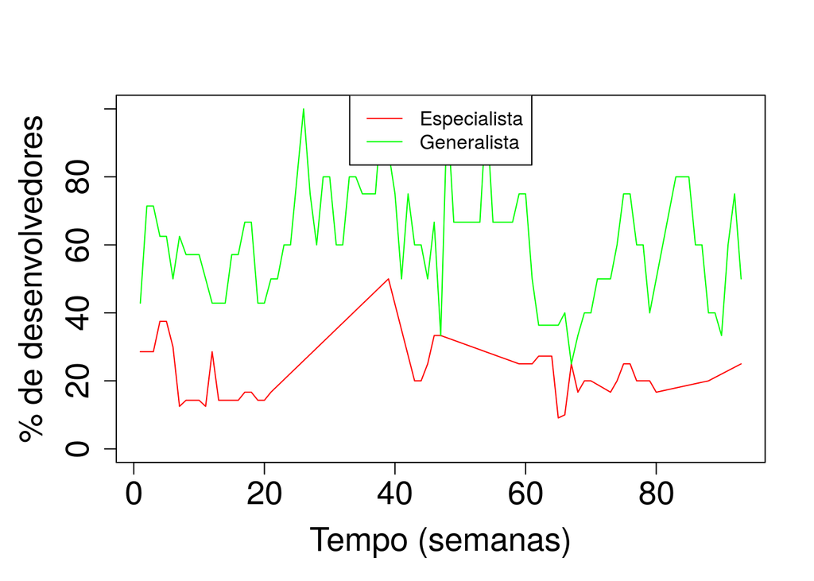

|  | esp | gen |
| --- | --- | --- |
| twosided | 0.9028886 | 0.4935806 |
| greater | 0.4514443 | 0.7532097 |
| less | 0.5485557 | 0.2467903 |

#### Allegro

0.3 [1] “

"

#### Evolução dos desenvolvedores ao longo do tempo

( janela 24 semanas, iteracao de 4 semanas) [1] “

"

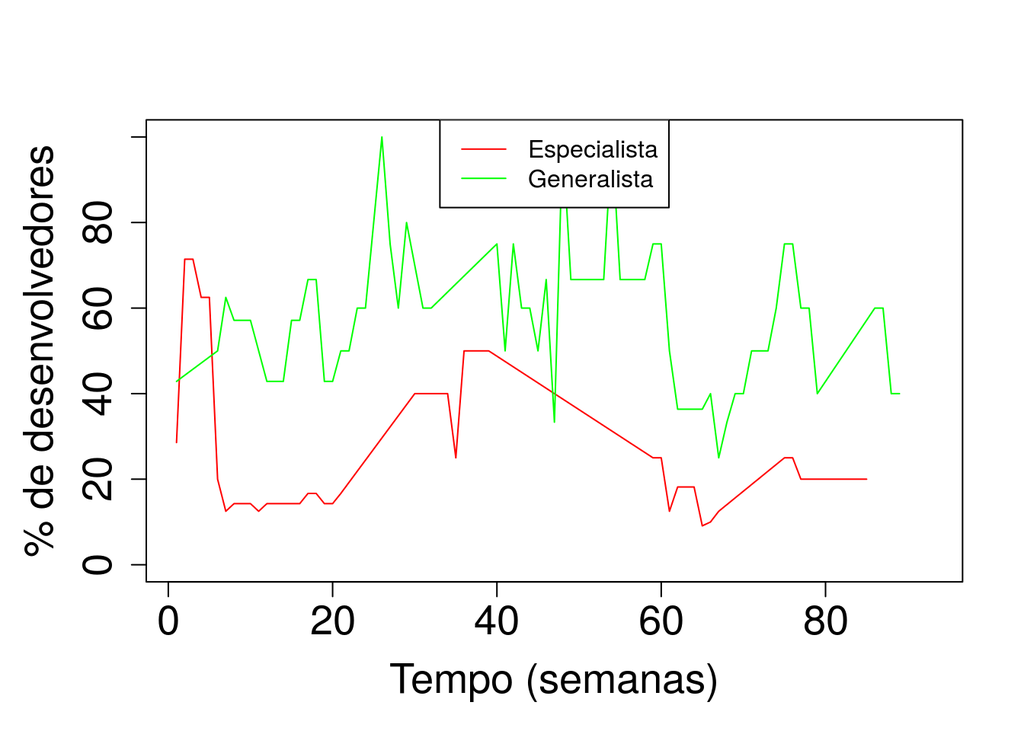

|  | esp | gen |
| --- | --- | --- |
| twosided | 0.9618704 | 0.6777843 |
| greater | 0.5190648 | 0.6611078 |
| less | 0.4809352 | 0.3388922 |

#### Allegro

0.4 [1] “

"

#### Evolução dos desenvolvedores ao longo do tempo

( janela 24 semanas, iteracao de 4 semanas) [1] “

"

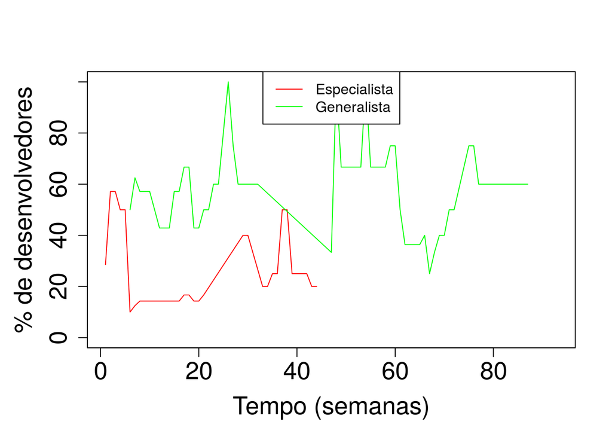

|  | esp | gen |
| --- | --- | --- |
| twosided | 0.2047001 | 0.8133391 |
| greater | 0.1023501 | 0.4066695 |
| less | 0.8976499 | 0.5933305 |

#### Allegro

0.5 [1] “

"

#### Evolução dos desenvolvedores ao longo do tempo

( janela 24 semanas, iteracao de 4 semanas) [1] “

"

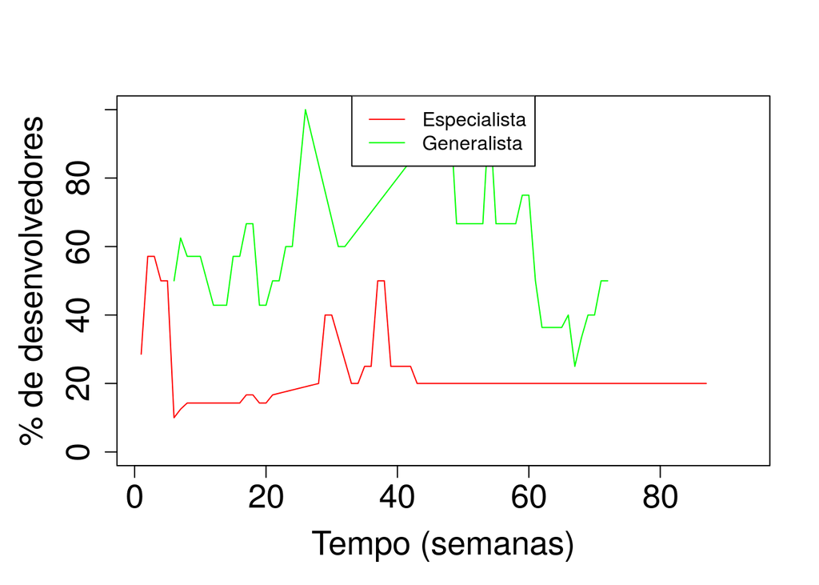

|  | esp | gen |
| --- | --- | --- |
| twosided | 0.1615725 | 0.5294383 |
| greater | 0.0807862 | 0.7352809 |
| less | 0.9192138 | 0.2647191 |

#### SDL

0.1 [1] “

"

#### Evolução dos desenvolvedores ao longo do tempo

( janela 24 semanas, iteracao de 4 semanas) [1] “

"

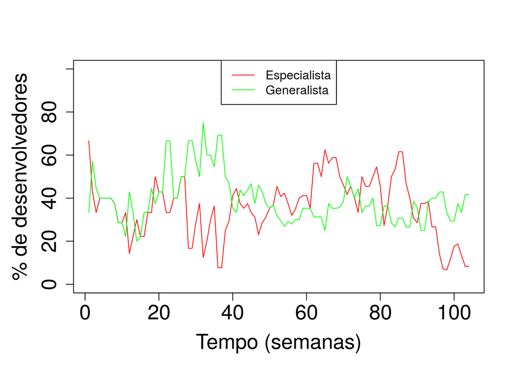

|  | esp | gen |
| --- | --- | --- |
| twosided | 0.6710770 | 0.0027144 |
| greater | 0.3355385 | 0.9986428 |
| less | 0.6644615 | 0.0013572 |

#### SDL

0.2 [1] “

"

#### Evolução dos desenvolvedores ao longo do tempo

( janela 24 semanas, iteracao de 4 semanas) [1] “

"

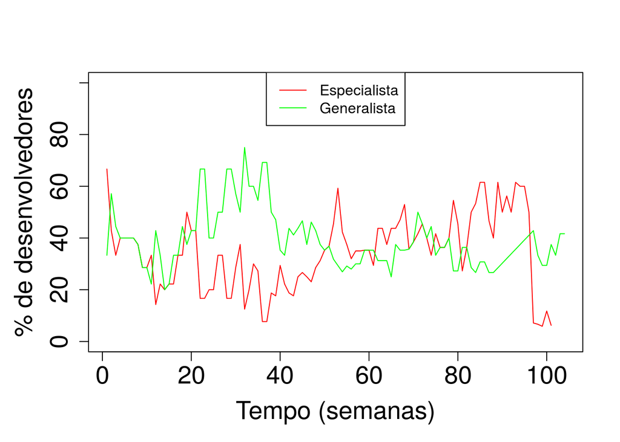

|  | esp | gen |
| --- | --- | --- |
| twosided | 0.0001035 | 0.0017893 |
| greater | 0.0000518 | 0.9991053 |
| less | 0.9999482 | 0.0008947 |

#### SDL

0.3 [1] “

"

#### Evolução dos desenvolvedores ao longo do tempo

( janela 24 semanas, iteracao de 4 semanas) [1] “

"

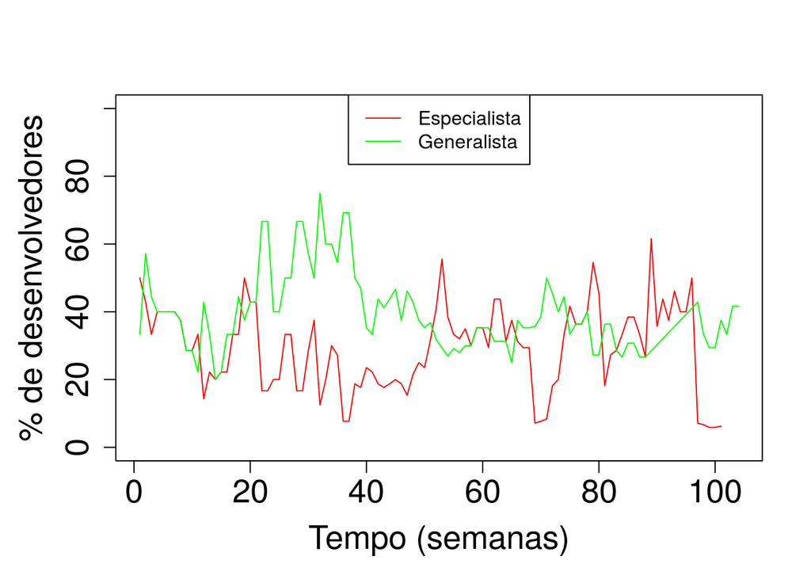

|  | esp | gen |
| --- | --- | --- |
| twosided | 0.6637268 | 0.0017893 |
| greater | 0.3318634 | 0.9991053 |
| less | 0.6681366 | 0.0008947 |

#### SDL

0.4 [1] “

"

#### Evolução dos desenvolvedores ao longo do tempo

( janela 24 semanas, iteracao de 4 semanas) [1] “

"

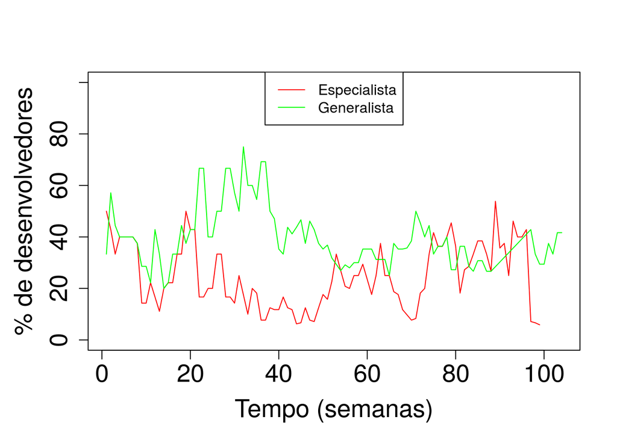

|  | esp | gen |
| --- | --- | --- |
| twosided | 0.3713867 | 0.0017893 |
| greater | 0.1856934 | 0.9991053 |
| less | 0.8143066 | 0.0008947 |

#### SDL

0.5 [1] “

"

#### Evolução dos desenvolvedores ao longo do tempo

( janela 24 semanas, iteracao de 4 semanas) [1] “

"

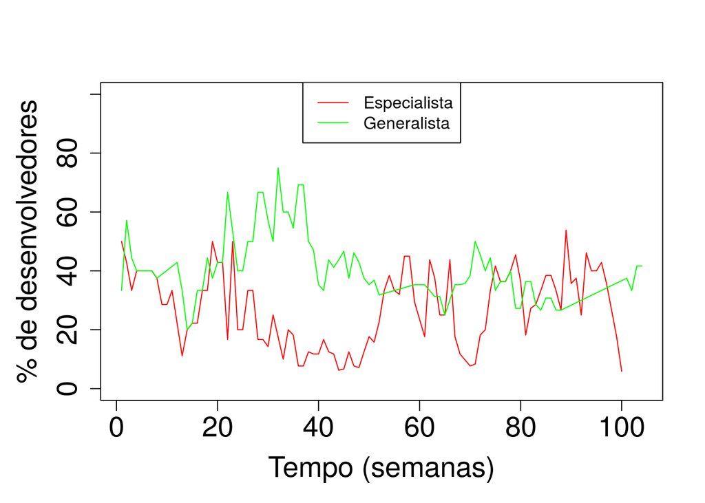

|  | esp | gen |
| --- | --- | --- |
| twosided | 0.5242762 | 0.0007029 |
| greater | 0.2621381 | 0.9996485 |
| less | 0.7378619 | 0.0003515 |

#### SFML

0.1 [1] “

"

#### Evolução dos desenvolvedores ao longo do tempo

( janela 24 semanas, iteracao de 4 semanas) [1] “

"

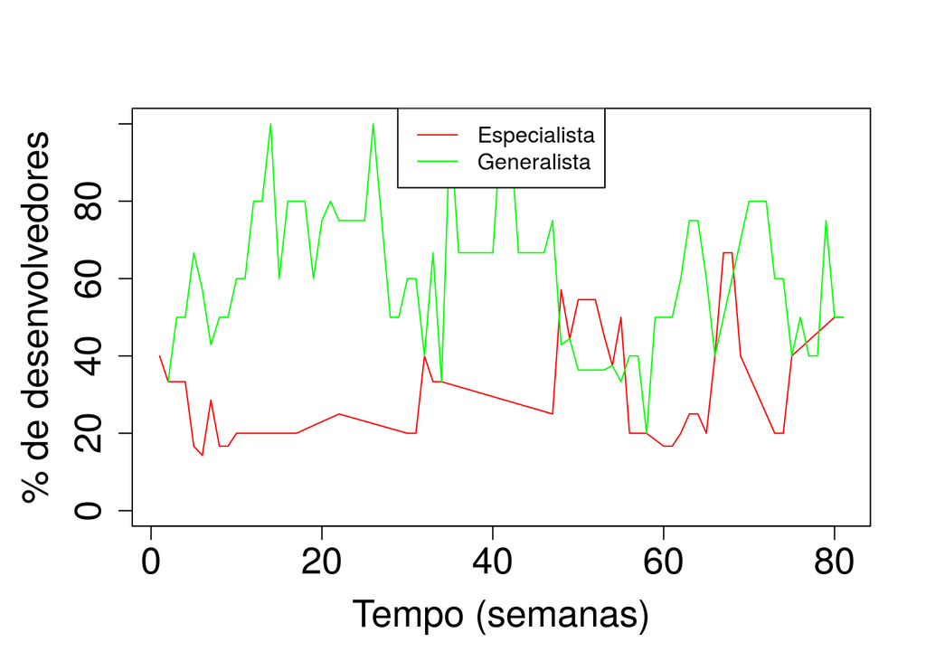

|  | esp | gen |
| --- | --- | --- |
| twosided | 0.0438986 | 0.0671581 |
| greater | 0.0219493 | 0.9664209 |
| less | 0.9780507 | 0.0335791 |

#### SFML

0.2 [1] “

"

#### Evolução dos desenvolvedores ao longo do tempo

( janela 24 semanas, iteracao de 4 semanas) [1] “

"

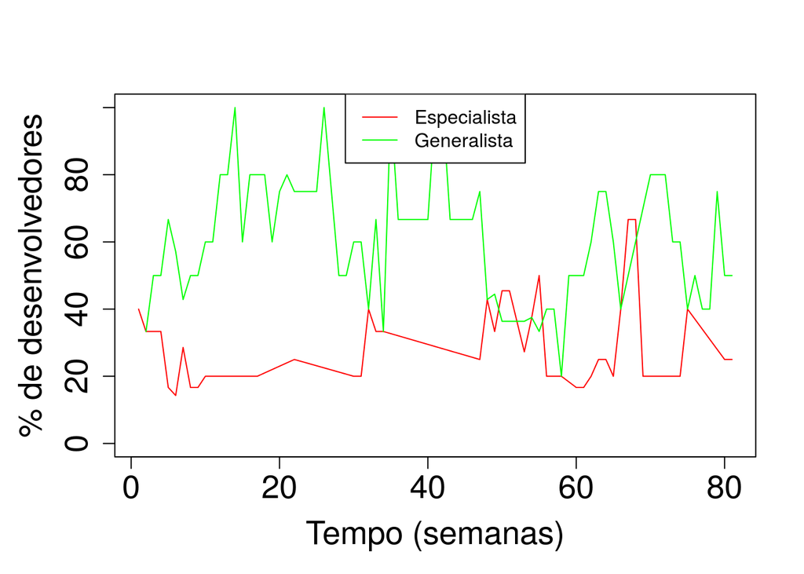

|  | esp | gen |
| --- | --- | --- |
| twosided | 0.2731359 | 0.0671581 |
| greater | 0.1365679 | 0.9664209 |
| less | 0.8634321 | 0.0335791 |

#### SFML

0.3 [1] “

"

#### Evolução dos desenvolvedores ao longo do tempo

( janela 24 semanas, iteracao de 4 semanas) [1] “

"

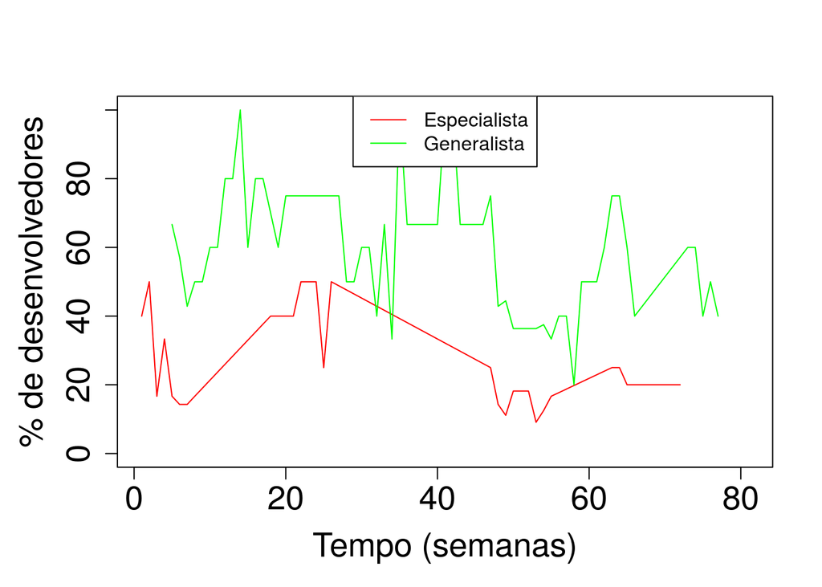

|  | esp | gen |
| --- | --- | --- |
| twosided | 0.3283009 | 0.0155517 |
| greater | 0.8358495 | 0.9922242 |
| less | 0.1641505 | 0.0077758 |

#### SFML

0.4 [1] “

"

#### Evolução dos desenvolvedores ao longo do tempo

( janela 24 semanas, iteracao de 4 semanas) [1] “

"

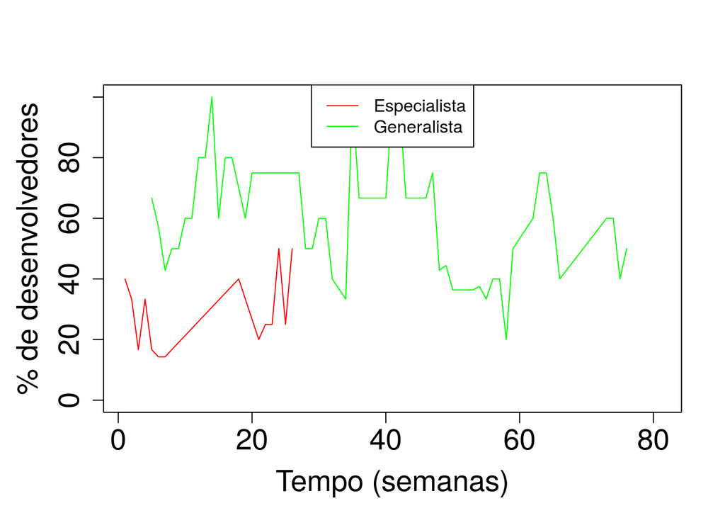

|  | esp | gen |
| --- | --- | --- |
| twosided | 0.3154889 | 0.0281274 |
| greater | 0.1577444 | 0.9859363 |
| less | 0.8422556 | 0.0140637 |

#### SFML

0.5 [1] “

"

#### Evolução dos desenvolvedores ao longo do tempo

( janela 24 semanas, iteracao de 4 semanas) [1] “

"

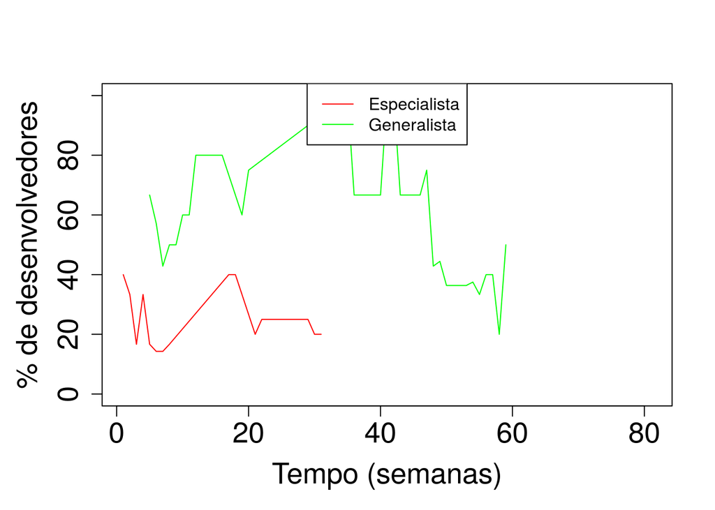

|  | esp | gen |
| --- | --- | --- |
| twosided | 0.7632393 | 0.0077319 |
| greater | 0.6183803 | 0.9961340 |
| less | 0.3816197 | 0.0038660 |

#### Coco2dx

0.1 [1] “

"

#### Evolução dos desenvolvedores ao longo do tempo

( janela 24 semanas, iteracao de 4 semanas) [1] “

"

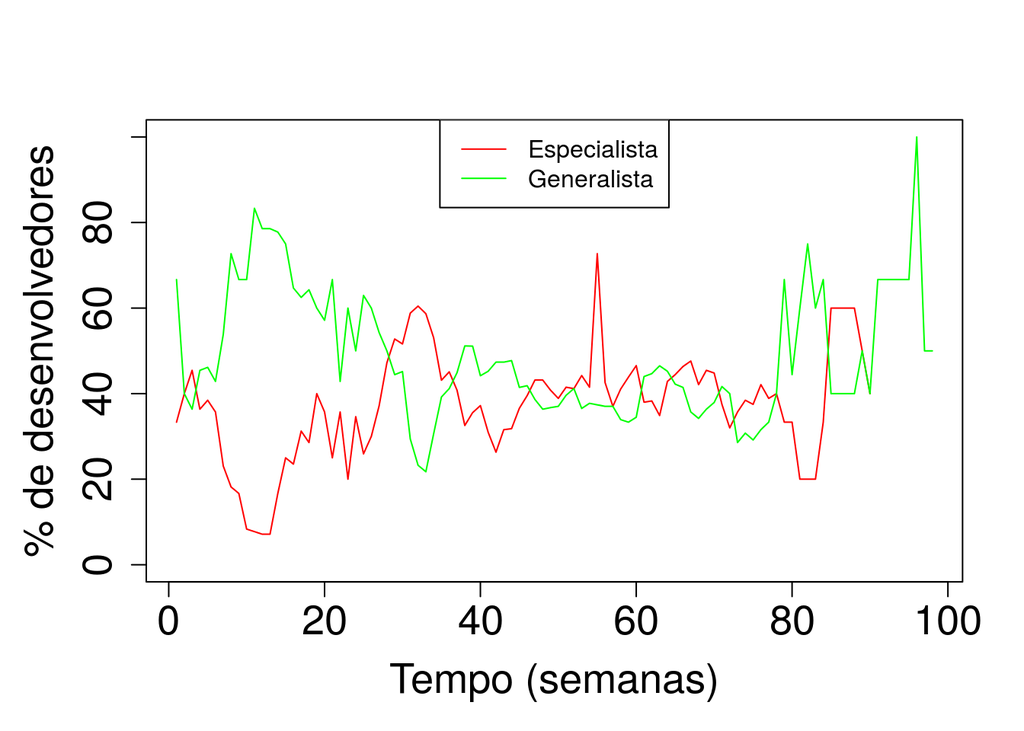

|  | esp | gen |
| --- | --- | --- |
| twosided | 0.0002751 | 0.0178477 |
| greater | 0.0001375 | 0.9910761 |
| less | 0.9998625 | 0.0089239 |

#### Coco2dx

0.2 [1] “

"

#### Evolução dos desenvolvedores ao longo do tempo

( janela 24 semanas, iteracao de 4 semanas) [1] “

"

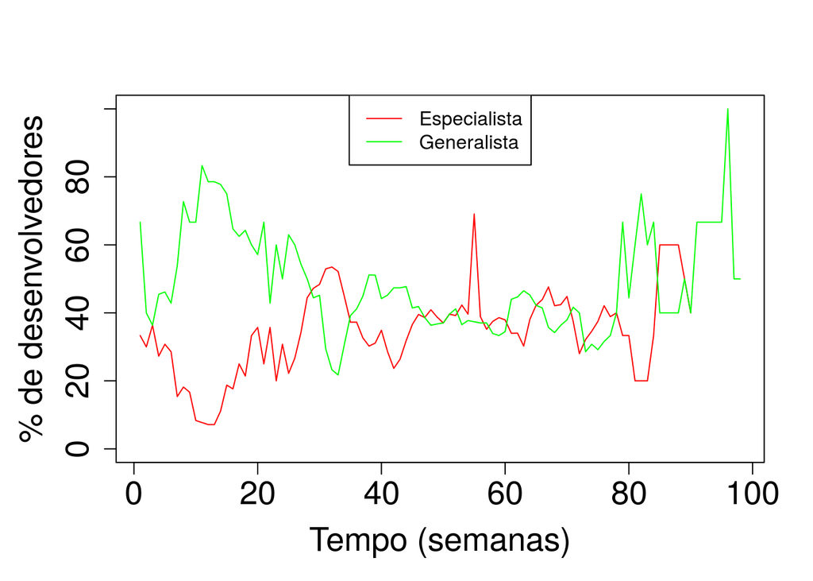

|  | esp | gen |
| --- | --- | --- |
| twosided | 0.0000008 | 0.0178477 |
| greater | 0.0000004 | 0.9910761 |
| less | 0.9999996 | 0.0089239 |

#### Coco2dx

0.3 [1] “

"

#### Evolução dos desenvolvedores ao longo do tempo

( janela 24 semanas, iteracao de 4 semanas) [1] “

"

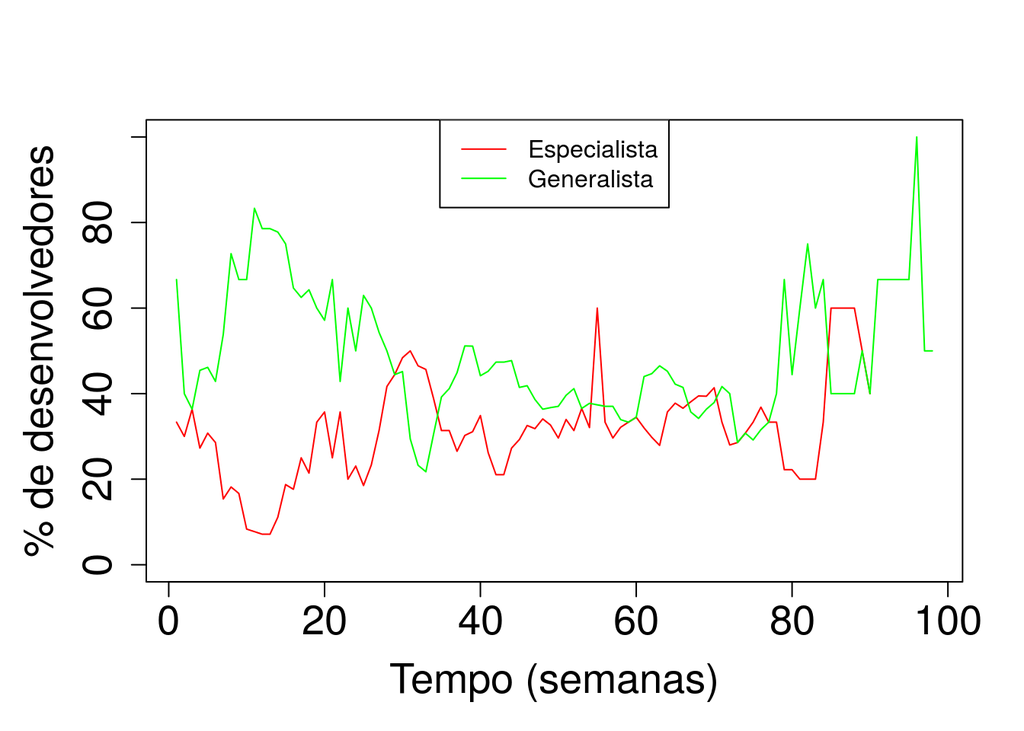

|  | esp | gen |
| --- | --- | --- |
| twosided | 0.0000273 | 0.0178477 |
| greater | 0.0000136 | 0.9910761 |
| less | 0.9999864 | 0.0089239 |

#### Coco2dx

0.4 [1] “

"

#### Evolução dos desenvolvedores ao longo do tempo

( janela 24 semanas, iteracao de 4 semanas) [1] “

"

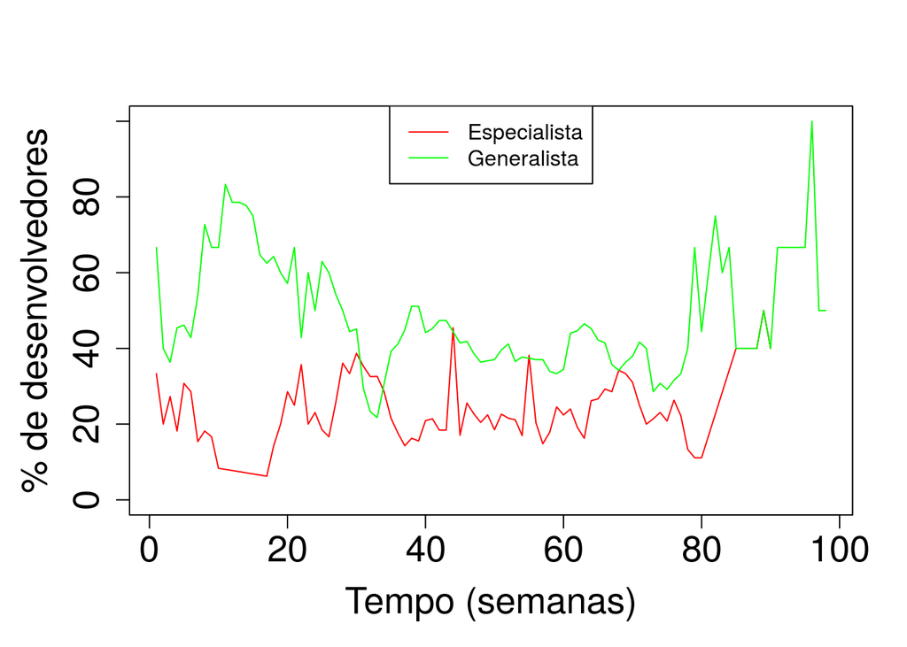

|  | esp | gen |
| --- | --- | --- |
| twosided | 0.0655792 | 0.0208495 |
| greater | 0.0327896 | 0.9895752 |
| less | 0.9672104 | 0.0104248 |

#### Coco2dx

0.5 [1] “

"

#### Evolução dos desenvolvedores ao longo do tempo

( janela 24 semanas, iteracao de 4 semanas) [1] “

"

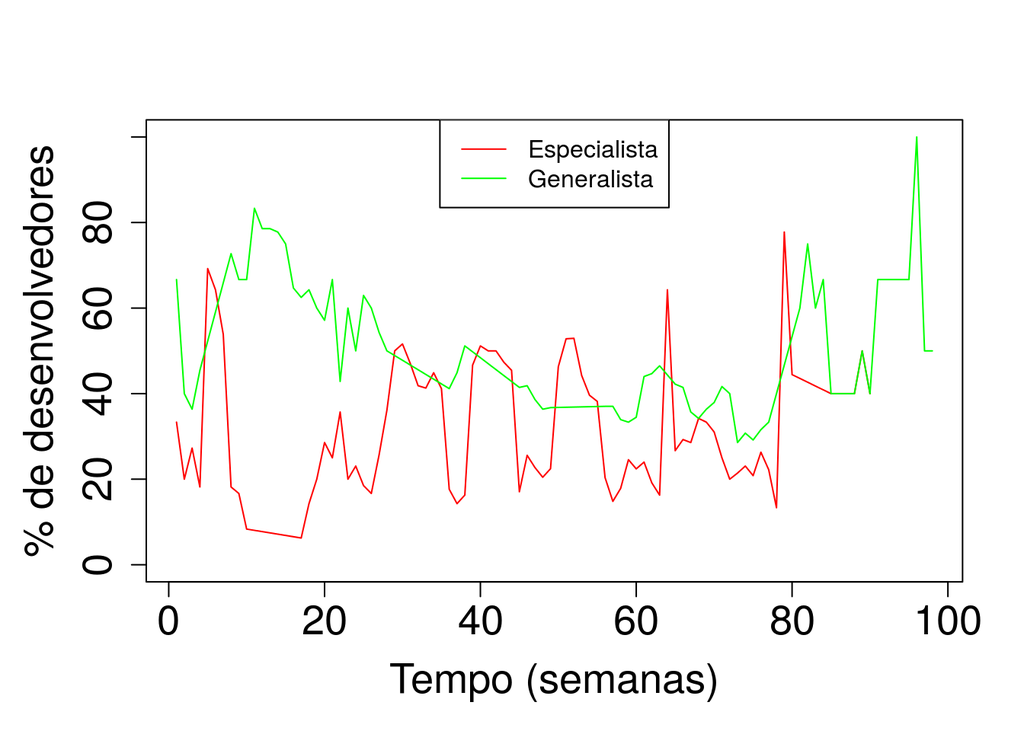

|  | esp | gen |
| --- | --- | --- |
| twosided | 0.3561753 | 0.0116967 |
| greater | 0.1780876 | 0.9941516 |
| less | 0.8219124 | 0.0058484 |

#### Godot

0.1 [1] “

"

#### Evolução dos desenvolvedores ao longo do tempo

( janela 24 semanas, iteracao de 4 semanas) [1] “

"

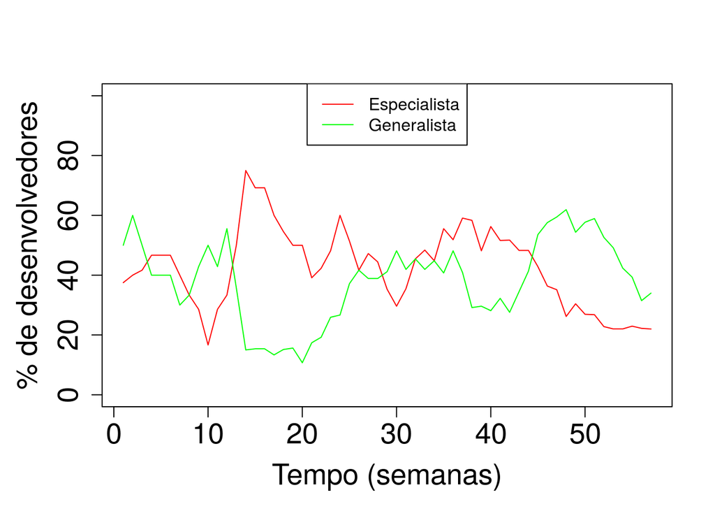

|  | esp | gen |
| --- | --- | --- |
| twosided | 0.0192108 | 0.0473531 |
| greater | 0.9903946 | 0.0236766 |
| less | 0.0096054 | 0.9763234 |

#### Godot

0.2 [1] “

"

#### Evolução dos desenvolvedores ao longo do tempo

( janela 24 semanas, iteracao de 4 semanas) [1] “

"

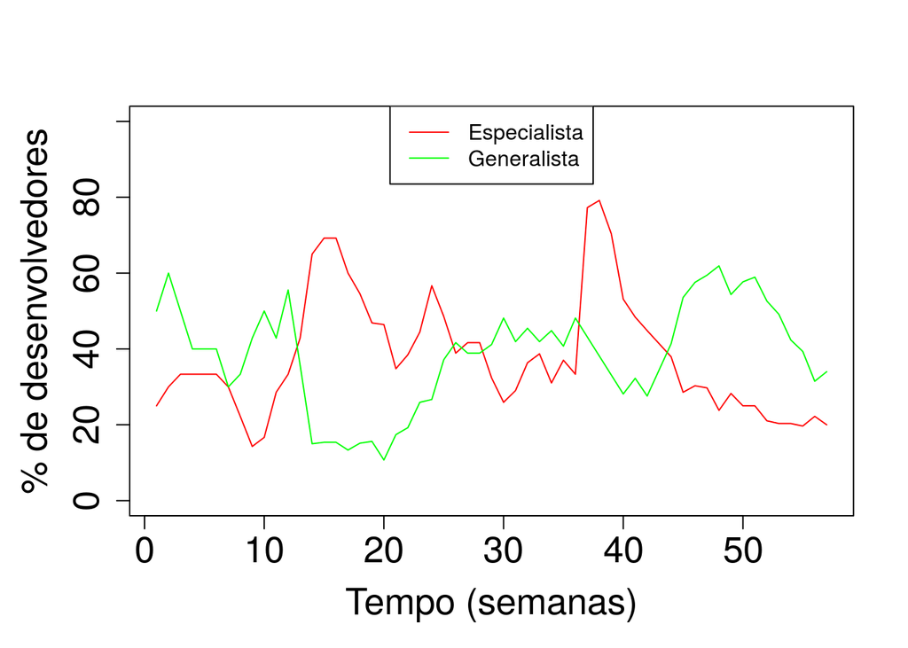

|  | esp | gen |
| --- | --- | --- |
| twosided | 0.0344089 | 0.0373272 |
| greater | 0.9827955 | 0.0186636 |
| less | 0.0172045 | 0.9813364 |

#### Godot

0.3 [1] “

"

#### Evolução dos desenvolvedores ao longo do tempo

( janela 24 semanas, iteracao de 4 semanas) [1] “

"

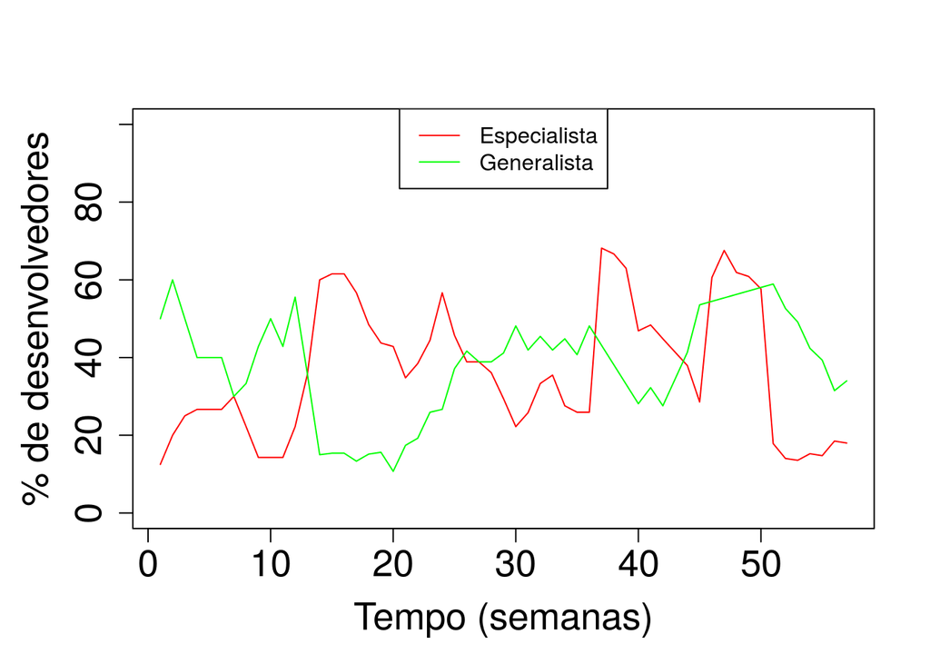

|  | esp | gen |
| --- | --- | --- |
| twosided | 0.5338533 | 0.3516627 |
| greater | 0.2669266 | 0.1758313 |
| less | 0.7330734 | 0.8241687 |

#### Godot

0.4 [1] “

"

#### Evolução dos desenvolvedores ao longo do tempo

( janela 24 semanas, iteracao de 4 semanas) [1] “

"

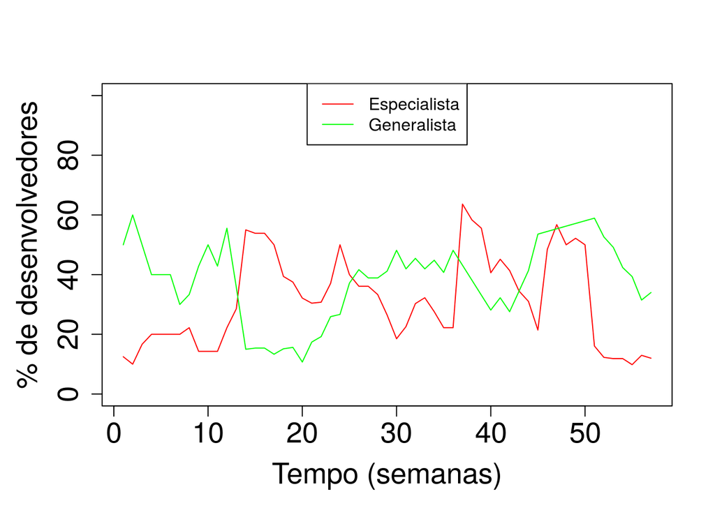

|  | esp | gen |
| --- | --- | --- |
| twosided | 0.492672 | 0.3516627 |
| greater | 0.246336 | 0.1758313 |
| less | 0.753664 | 0.8241687 |

#### Godot

0.5 [1] “

"

#### Evolução dos desenvolvedores ao longo do tempo

( janela 24 semanas, iteracao de 4 semanas) [1] “

"

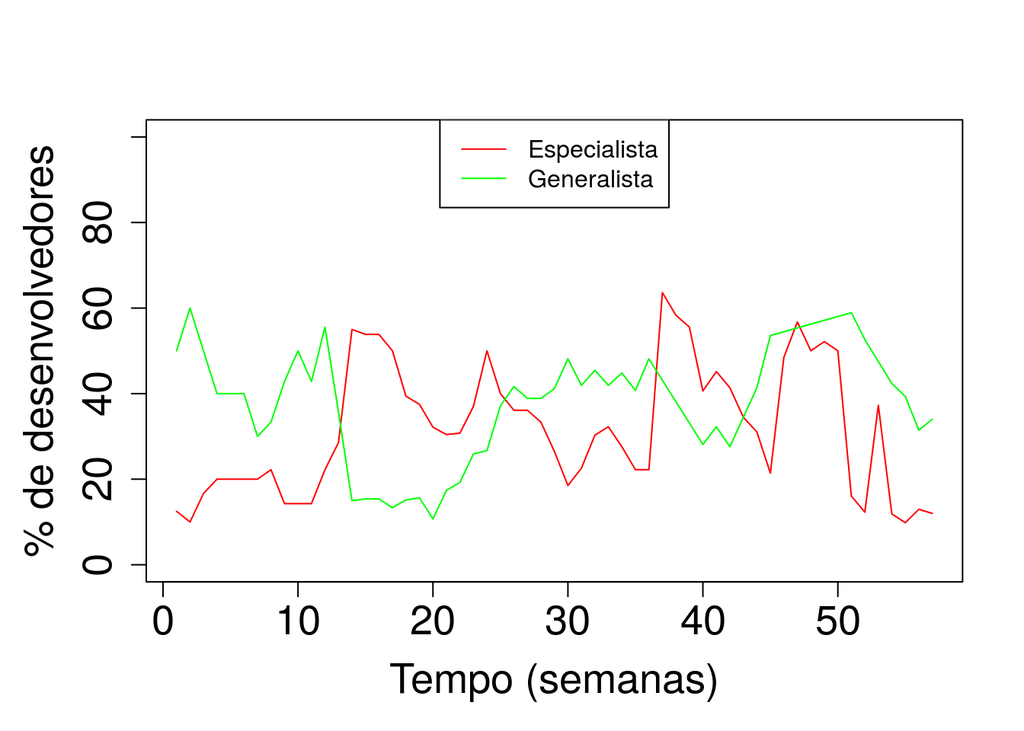

|  | esp | gen |
| --- | --- | --- |
| twosided | 0.2760703 | 0.4550881 |
| greater | 0.1380352 | 0.2275440 |
| less | 0.8619648 | 0.7724560 |